# Differences in Labor Force Participation Rates Between Genders

Author

Justin Hamilton and Josh Rubin

## Data source

[IPUMS USA](https://www.ipums.org)

## Load IPUMS data

```r
# install.packages("ipumsr")
library(ipumsr)

if (!require("ipumsr")) stop("Reading IPUMS data into R requires the ipumsr package. It can be installed using the following command: install.packages('ipumsr')")

ddi <- read_ipums_ddi("usa_00043.xml")
data <- read_ipums_micro(ddi)
```

## Distribution of usual hours worked by gender

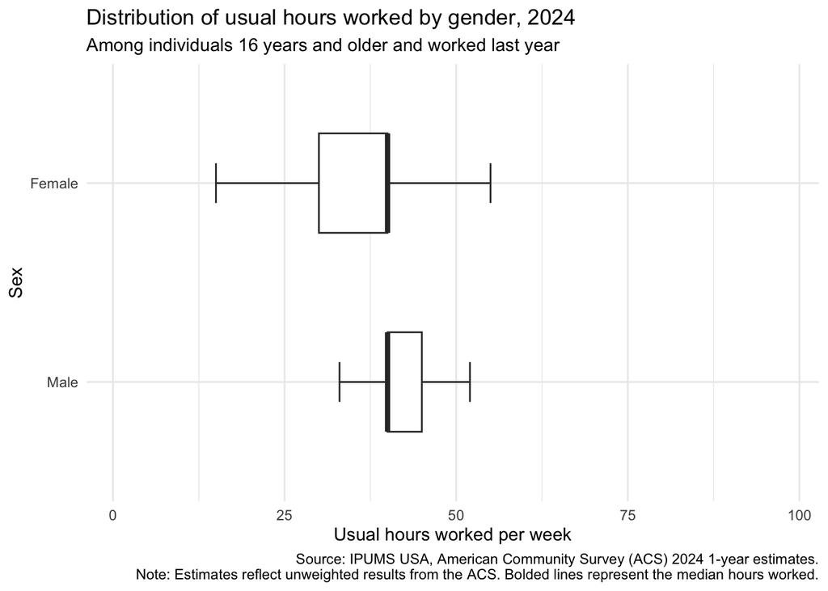

```r
library(tidyverse)

data |>
  filter(AGE > 15 & WKSWORK1 > 0) |>
  mutate(
    UHRSWORK = ifelse(UHRSWORK == 99, NA, UHRSWORK)
  ) |>
  ggplot(mapping = aes(x = UHRSWORK, y = factor(SEX))) +
  geom_boxplot(
    outlier.shape = NA,
    width = 0.5,
    staplewidth = 0.4,
    median.linewidth = 1.5) +
  labs(
    title = "Distribution of usual hours worked by gender, 2024",
    subtitle = "Among individuals 16 years and older and worked last year",
    caption = "Source: IPUMS USA, American Community Survey (ACS) 2024 1-year estimates.\nNote: Estimates reflect unweighted results from the ACS. Bolded lines represent the median hours worked."
  ) +
  scale_y_discrete(
    name = "Sex",
    labels = c("1" = "Male", "2" = "Female")
  ) +
  xlab("Usual hours worked per week") +
  theme_minimal()
```

Males and females have the same median usual hours worked per week (~ 40 hours). However, the distribution of hours worked for males is much more tightly concentrated around the median than the distribution of hours worked for females. In general, females have greater variation in weekly hours worked. This increased variation from females may reflect familial responsibilities outside of work in addition to females generally being more marginally attached to workforce than males.

## Labor force participation rate by gender

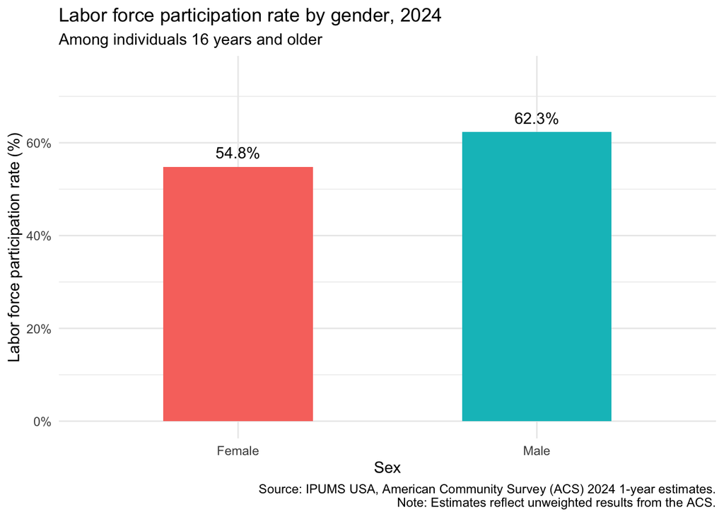

```r
lfpr_data <- data |>
  filter(AGE > 15 & LABFORCE != 0) |>
  mutate(
    LABFORCE = case_when(
      LABFORCE == 2 ~ 1,
      LABFORCE == 1 ~ 0,
      TRUE ~ NA
    ),
    sex_clean = ifelse(SEX == 1, "Male", "Female")
  ) |>
  group_by(sex_clean) |>
  summarize(
    LFPR = mean(LABFORCE, na.rm = TRUE)
  )

ggplot(data = lfpr_data, mapping = aes(x = sex_clean, y = LFPR, fill = sex_clean)) +
  geom_bar(stat = "identity", width = 0.5) +
  geom_text(
    mapping = aes(label = scales::percent(LFPR, accuracy = 0.1)),
    vjust = -0.75) +
  labs(
    title = "Labor force participation rate by gender, 2024",
    subtitle = "Among individuals 16 years and older",
    caption = "Source: IPUMS USA, American Community Survey (ACS) 2024 1-year estimates.\nNote: Estimates reflect unweighted results from the ACS."
  ) +
  scale_y_continuous(labels = scales::label_percent(), limits = c(0,0.75)) +
  xlab("Sex") +
  ylab("Labor force participation rate (%)") +
  theme_minimal() +
  theme(legend.position = "none")
```

Male labor force is rougly 7.5 percentage points higher than female labor force participation (62.3% vs. 54.8%). This difference, like variation in hours worked, may reflect familial responsibilities outside of work in addition to females generally being more marginally attached to workforce than males. Lower female labor force participation presents a potential point of deadweight loss if these individuals want to work but cannot due to barriers to employment or other circumstances.

## Labor force participation rate differences by marital status and gender

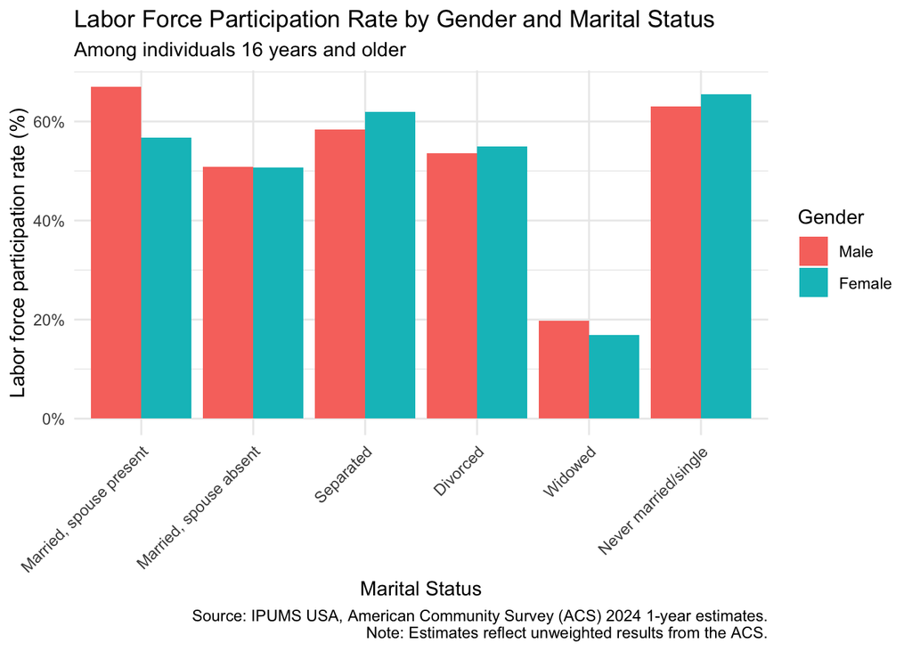

```r
lfpr_gender_mar <- data |>
  filter(AGE > 15, LABFORCE != 0) |>
  mutate(
    LABFORCE = case_when(
      LABFORCE == 2 ~ 1,
      LABFORCE == 1 ~ 0,
      TRUE ~ NA
      )
  ) |>
  group_by(SEX, MARST) |>
  summarize(lfpr = mean(LABFORCE, na.rm = TRUE))

lfpr_gender_mar |>
  ggplot() +
  geom_col(aes(x = factor(MARST), y = lfpr, fill = factor(SEX)), position = "dodge") +
  labs(
    title = "Labor Force Participation Rate by Gender and Marital Status",
    subtitle = "Among individuals 16 years and older",
    x = "Marital Status",
    y = "Labor force participation rate (%)",
    fill = "Gender",
    caption = "Source: IPUMS USA, American Community Survey (ACS) 2024 1-year estimates.\nNote: Estimates reflect unweighted results from the ACS."
  ) +
  scale_y_continuous(labels = scales::label_percent()) +
  scale_x_discrete(labels = c(
    "1" = "Married, spouse present",
    "2" = "Married, spouse absent",
    "3" = "Separated",
    "4" = "Divorced",
    "5" = "Widowed",
    "6" = "Never married/single"
    )) +
  scale_fill_discrete(labels = c(
    "1" = "Male",
    "2" = "Female"
    )) +
  theme_minimal() +
  theme(
    axis.text.x = element_text(angle = 45, hjust = 1, vjust = 1)
  )
```

The differences in labor force participation between married (spouse present) males and females is particularly interesting here, especially when we observe that no such difference exists for those married where the spouse is absent. Among those married with a spouse present, females have about a 10 percentage point lower participation rate than males. No such difference exist in any other marital category. While the previous point about potential barriers for females is important, we must also consider that some of this difference can be attributed to preferences rather than systemic issue. Married females with a spouse present might be less likely to work because they have the option not to if their spouse works.

## Relationship between state education levels and labor force participation rate by gender

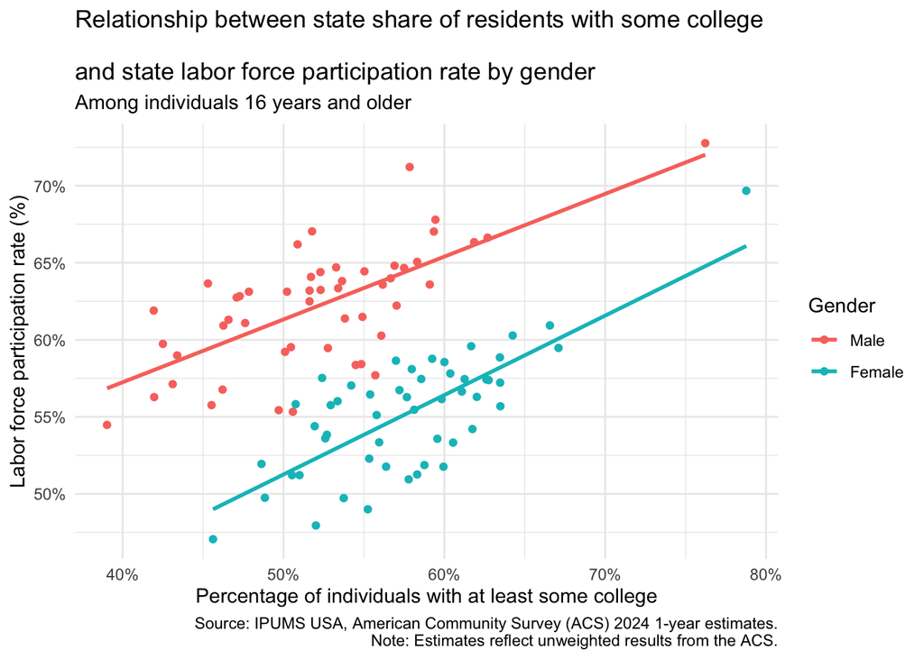

```r
state_data <- data %>%
  filter(AGE > 15, EDUC != 0, LABFORCE != 0) %>%
  mutate(
    LABFORCE = case_when(
      LABFORCE == 2 ~ 1,
      LABFORCE == 1 ~ 0,
      TRUE ~ NA
      ),
    COLLEGE = ifelse(
      EDUC >= 7,
      1,
      0
    )
  ) %>%
  group_by(SEX, STATEFIP) %>%
  summarize(
    LFPR = mean(LABFORCE, na.rm = TRUE),
    COLLEGE_PERC = mean(COLLEGE, na.rm = TRUE)
  )

state_data %>%
  ggplot(aes(x = COLLEGE_PERC, y = LFPR, color = factor(SEX))) +
  geom_point() +
  geom_smooth(se = FALSE, method = "lm") +
  labs(
    title = "Relationship between state share of residents with some college
    \nand state labor force participation rate by gender",
    subtitle = "Among individuals 16 years and older",
    x = "Percentage of individuals with at least some college",
    y = "Labor force participation rate (%)",
    color = "Gender",
    caption = "Source: IPUMS USA, American Community Survey (ACS) 2024 1-year estimates.\nNote: Estimates reflect unweighted results from the ACS."
  ) +
  scale_y_continuous(labels = scales::label_percent()) +
  scale_x_continuous(labels = scales::label_percent()) +
  scale_color_discrete(labels = c(
    "1" = "Male",
    "2" = "Female"
    )) +
  theme_minimal()
```

The above graph shows that there is an association between a state’s percentage of individuals with at least some college education and a state’s labor force participation rate. States with higher percentages of college educated individuals tend to have higher participation rates. It appears to be present for both males and females, possibly slightly greater (steeper slope) for females. If we are interested in increasing female labor force participation, this suggests that a potential policy lever could be increasing access to college education. Of course, more rigerous research is needed.

## Visualization Requirements Checklist

| Requirement Category | Specific Element / Code Used | Graph # (1, 2, 3, or 4) |
| --- | --- | --- |
| **Geom 1** | `geom_point()` | 4 |
| **Geom 2** | `geom_bar()` | 2 |
| **Geom 3** | `geom_smooth()` | 4 |
| **Geom 4** | `geom_boxplot()` | 1 |
| **Geom 5** | `geom_text()` | 2 |
| **Aesthetic 1** *(inside `aes()`)* | `x = COLLEGE_PERC` | 4 |
| **Aesthetic 2** *(inside `aes()`)* | `y = LFPR` | 4 |
| **Aesthetic 3** *(inside `aes()`)* | `color = factor(SEX)` | 4 |
| **Aesthetic 4** *(inside `aes()`)* | `x = factor(MARST)` | 3 |
| **Aesthetic 5** *(inside `aes()`)* | `x = UHRSWORK` | 1 |
| **Aesthetic 6** *(inside `aes()`)* | `fill = factor(SEX)` | 3 |
| **Non-Aesthetic 1** *(outside `aes()`)* | `se = FALSE` | 4 |
| **Non-Aesthetic 2** *(outside `aes()`)* | `method = "lm"` | 4 |
| **Non-Aesthetic 3** *(outside `aes()`)* | `position = "dodge"` | 3 |
| **Non-Aesthetic 4** *(outside `aes()`)* | `outlier.shape = NA` | 1 |
| **Non-Aesthetic 5** *(outside `aes()`)* | `width = 0.5` | 1 |
| **Non-Aesthetic 6** *(outside `aes()`)* | `vjust = -0.75` | 2 |
| **Custom Scale 1** | `scale_y_continuous(labels = scales::label_percent())` | 4 |
| **Custom Scale 2** | `scale_y_discrete(name = "Sex", labels = c("1" = "Male", "2" = "Female"))` | 1 |